# Red Squirels - LTEM - West Arm Park

Published

2023-02-23

# 1 Summary of Red Squirrel LTEM protocol

## 1.1 Basic protocol

As taken from the protocol document:

> “Red squirrels regularly emit an audible rattle, especially when their territories are invaded. This protocol involves walking a transect (a section of a trail) and recording the location of rattles heard along the way.

For this protocol, locate as many transects in a given area as possible (up to 5). Sample them annually but in a different order each year. Sampling involves walking a defined segment of trail and recording squirrel rattles or chattering.

The data collected under this protocol consists of the.

- Detection Type. Was a call heard, a visual observation made or other evidence of a squirrel. Only calls will be used in this analysis
- Distance along the transect. The location of the observer along the transect when the detection was made.
- Distance from the transect. The perpendicular distance from the transect line to the observation along with the side of the transect.

## 1.2 Cautions about the protocol.

### 1.2.1 Don’t use 0 to indicate a missing value.

If no calls were heard on a transect, how is this indicated? For example, in the 2013 data table, there is NO observation for transect 4 on 2013-09-13. Does this mean that the transect was not run, or was it run and no squirrels were detected? The Transect Information sheet in the workbook has the GPS co-ordinates of each transect, but does not indicate if the transect was run on each of the days.

It will be assume that ALL transects listed in the database were run and have 0 already imputed.

### 1.2.2 No information on transect length available

. There is no information about the length of each transect or if each transect was visited on its entirety each visit. It will be assumed that each transect is approximately equal in length and that the entire transect is visited on a visit.

### 1.2.3 Not suitable for distance sampling to estimate density.

The current data looks very similar to captured by distance sampling methods where RANDOM transects are selected in the study area and the perpendicular distance of observations to the transect are selected. Distance sampling is used to estimate density.

In this protocol, transects are not selected at random. Indeed, according to the protocol,

> “Find a location that is not difficult to access and where there are abundant squirrels.”

So the apparent density of squirrels may be biased upwards by the selection of transects

### 1.2.4 Be careful to document changes in transect over time.

The protocol is silent on how to document changes in transects over time. For example, suppose that a transect is damaged by fire? How is this recorded? Suppose that a transect is abandoned and new transect is chosen. At the very least, the transect label should NOT be recycled over time.

### 1.2.5 Not clear how to group visits.

The date that the transects are visited is also recorded. It is assumed that all transects will be visited on the same date. However, in some cases, the transects are visited over a span of 2 or 3 day – these should presumably be “pooled” into one visit. At the moment, there is no way to decide if all transects were visited on a single day, or if a “visit” corresponds to more than one day. A field should be added to the data base for the “visit”, e.g., if it takes several days to visit all transects, these should be either be recorded on the first date, or all take the same visit indicator.

## 1.3 Database structure

The relevant fields extracted from the database are:

- *Transect Label*.
- *Date*. The date the data was collected. The Year is extracted from this date.
- *Count*. The number of calls heard on the transect on that date. It is assumed that 0’s have been already imputed on the database.

# 2 Reading and checking the data

The database was queried for all observations from West Arm Park.

The following surveys were found:

```
Surveys with the data
```

```
   SPI_PROJECT_ID SURVEY_ID          START_DATE STUDY_AREA_NAME
28           5569     35405 2015-10-13 17:00:00   West Arm Park
31           5569     35408 2016-09-20 17:00:00   West Arm Park
34           5569     35411 2017-10-02 17:00:00   West Arm Park
```

The following data editing was performed

## 2.1 Variables names corrected for *R*

Variable names in *R* must start with a letter and contain letters or numbers or underscores. Blanks in variable names are not normally allowed, nor are special characters such as %. These are normally replaced by periods (“.”) in the variable name.

```
Original variable names in squirrels data file
```

```
  [1] "DESIGN_COMPONENT_ID"            "TAXONOMIC_UNIT_ID"
  [3] "SURVEY_ID"                      "SPI_PROJECT_ID"
  [5] "STUDY_AREA_ID"                  "STUDY_AREA_VISIT_ID"
  [7] "DESIGN_COMPONENT_VISIT_ID"      "VISIT_START_DATE"
  [9] "VISIT_START_TIME"               "OBSERVATION_DATETIME"
 [11] "OBSERVATION_YEAR"               "OBSERVATION_MONTH"
 [13] "OBSERVATION_DAY"                "VISIT_END_DATE"
 [15] "VISIT_END_TIME"                 "VISIT_TIME_SPAN"
 [17] "VISIT_TIME_SPAN_UNIT_CODE"      "VISIT_TIME_SPAN_UNIT_NAME"
 [19] "VISIT_TIME_SPAN_UNIT_DEFN_URL"  "TRAP_EVENT_CODE"
 [21] "TRAP_EVENT_NAME"                "TRAP_EVENT_DEFN_URL"
 [23] "TRAPS_SPRUNG"                   "DISTANCE_COVERED_KM"
 [25] "NIGHTS_TRAPPED"                 "SAMPLES"
 [27] "VISIT_NOTE"                     "NO_OBSERVATIONS_IND"
 [29] "TRIGGER_QUIET_PERIOD_SEC"       "TRIGGER_SENSITIVITY"
```

[output cut: 44 more lines]

```
Corrected variable names of data frame
```

```
  [1] "DESIGN_COMPONENT_ID"            "TAXONOMIC_UNIT_ID"
  [3] "SURVEY_ID"                      "SPI_PROJECT_ID"
  [5] "STUDY_AREA_ID"                  "STUDY_AREA_VISIT_ID"
  [7] "DESIGN_COMPONENT_VISIT_ID"      "VISIT_START_DATE"
  [9] "VISIT_START_TIME"               "OBSERVATION_DATETIME"
 [11] "OBSERVATION_YEAR"               "OBSERVATION_MONTH"
 [13] "OBSERVATION_DAY"                "VISIT_END_DATE"
 [15] "VISIT_END_TIME"                 "VISIT_TIME_SPAN"
 [17] "VISIT_TIME_SPAN_UNIT_CODE"      "VISIT_TIME_SPAN_UNIT_NAME"
 [19] "VISIT_TIME_SPAN_UNIT_DEFN_URL"  "TRAP_EVENT_CODE"
 [21] "TRAP_EVENT_NAME"                "TRAP_EVENT_DEFN_URL"
 [23] "TRAPS_SPRUNG"                   "DISTANCE_COVERED_KM"
 [25] "NIGHTS_TRAPPED"                 "SAMPLES"
 [27] "VISIT_NOTE"                     "NO_OBSERVATIONS_IND"
 [29] "TRIGGER_QUIET_PERIOD_SEC"       "TRIGGER_SENSITIVITY"
```

[output cut: 44 more lines]

## 2.2 How many years of data are available?

```
The number of TRANSECTS run by year are
```

```
               Year
STUDY_AREA_NAME 2015 2016 2017
  West Arm Park   27   54   34
```

## 2.3 Checking Study Area Name

The Study Area Name should be recorded consistently across years, otherwise it may indicate that different sites are being studied. The study area name is converted to Title Case.

The list of number of transects by each combination of Study Area Names by year in the data is:

```
               Year
STUDY_AREA_NAME 2015 2016 2017
  West Arm Park   27   54   34
```

## 2.4 Checking species code

The species code should be the same across for all data values.. Note that in many years, a code of *NULL* was entered to indicate no squirrels of any species were detected. **This table shows the total detections for each species.year combination over all the transects**

```
            Year
SPECIES_CODE 2015 2016 2017
      M-TAHU   20   53   31
      NULL      0    0    0
```

```
*** WARNING *** More than one species name found - OK if some are NULL
```

## 2.5 Summarized data to the Year.Transect level

We summarize the data to mean number of calls per year per transect.

```
   STUDY_AREA_NAME Year TRANSECT mean.calls
1    West Arm Park 2015        1  1.0000000
2    West Arm Park 2015        2  0.0000000
3    West Arm Park 2015        3  0.3333333
4    West Arm Park 2015        4  1.0000000
5    West Arm Park 2015        5  0.3333333
6    West Arm Park 2016        1  1.0000000
7    West Arm Park 2016        2  1.0000000
8    West Arm Park 2016        3  0.8000000
9    West Arm Park 2016        4  1.0000000
10   West Arm Park 2016        5  1.0000000
11   West Arm Park 2017        1  1.0000000
12   West Arm Park 2017        2  0.8571429
13   West Arm Park 2017        3  1.0000000
14   West Arm Park 2017        4  0.6000000
15   West Arm Park 2017        5  1.0000000
```

# 3 Single Site Analysis

Date for the West Arm Park are available from 2015 to 2017.

This design has multiple transects that are repeatedly measured over time. Please refer to the Fitting Trends with Complex Study Designs document in the CommonFile directory for information on fitting trends with complex study designs.

All analyses were done using the R (R Core Team, 2022) analysis system. All plots are also saved as separate *png files for inclusion into other reports.

## 3.1 Calls.

The data is first summarized to the transect-year level by finding the mean number of calls on a transect over multiple visits for each individual transect. This reduces the data to one measurement per transect per site/year. It is implicitly assumed that all transects are run on all days within a so every transect has the same number of days of measurement. If transects are changed over time, that is not a problem, but transects should not be introduced or removed part way through a year.

A summary plot of the mean number of calls on each transect is shown in Figure 1.

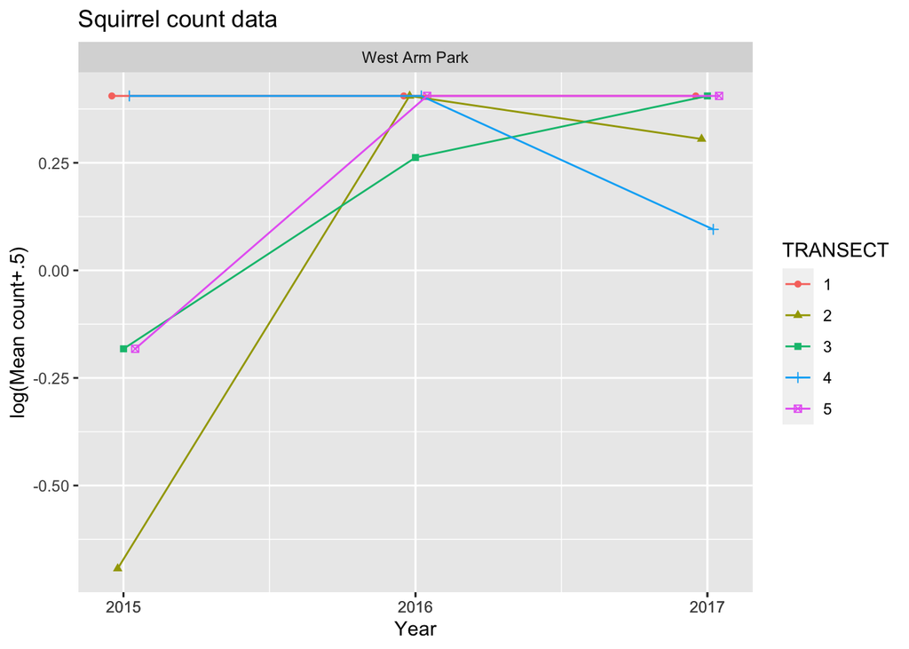

Figure 1: Summary plot of the data. The data is analyzed on the logarithmic scale.

There may be evidence of a transect effect, where, for example, the number of calls at certain transects could generally be higher than at the other transects because of local transect-specific conditions (e.g. better habitat).

Because this is count data, a linear mixed model is fit to the logarithm of the mean calls per transect. The model is:

$$log(AvgCalls+.5) \sim \mathit{Year} + \mathit{TransectF(R)} + \mathit{YearF(R)}$$
where

- $log(AvgCalls)$ is logarithm of the average number of calls for that transect in that year. An offset of 0.5 is used to avoid taking the logarithm of 0.
- $\mathit{TransectF(R)}$ represents the (random)transect effect;
- $\mathit{YearF(R)}$ represents the (random) year-specific effects (process error), and
- $\mathit{Year}$ term represents the calendar year trend over time.

The $\mathit{TransectF}$ term allows for the fact that transect-specific conditions may tend to affect the counts on this transect consistently over time. The $\mathit{YearF}$ term represent the year-specific effects (process error) caused by environmental factors (e.g., a warmer than normal year may elicit more calls from squirrels).

Model fit on the logarithmic scale assume that effects are multiplicative over time, so that the when the actual fit is done on the logarithmic scale, the trends are linear. For example, a trend may assume that there is constant 5% change over time rather than a fixed 1-unit change per year. Some caution is needed if any of the values are 0 as log(0) is not defined. In these cases, a small constant (typically ½ of the smallest positive value in the dataset) is added to all values before the analysis proceeds.

The model was fit using the *lmer()* function in *R*.

```
boundary (singular) fit: see help('isSingular')
```

```
Type III Analysis of Variance Table with Kenward-Roger's method
      Sum Sq Mean Sq NumDF DenDF F value Pr(>F)
Year 0.14384 0.14384     1     1  1.8122 0.4067
```

```
Linear mixed model fit by REML. t-tests use Satterthwaite's method [
lmerModLmerTest]
Formula: log(mean.calls + 0.5) ~ Year + (1 | TRANSECTF) + (1 | YearF)
   Data: count.transect

REML criterion at convergence: 9.8

Scaled residuals:
    Min      1Q  Median      3Q     Max
-2.4025 -0.3854  0.1737  0.3365  1.4970

Random effects:
 Groups    Name        Variance  Std.Dev.
 TRANSECTF (Intercept) 3.028e-10 0.0000174
 YearF     (Intercept) 2.247e-02 0.1498953
 Residual              7.937e-02 0.2817337
Number of obs: 15, groups:  TRANSECTF, 5; YearF, 3

Fixed effects:
             Estimate Std. Error        df t value Pr(>|t|)
(Intercept) -375.5548   279.1391    1.0004  -1.345    0.407
Year           0.1864     0.1385    1.0004   1.346    0.407

Correlation of Fixed Effects:
     (Intr)
Year -1.000
optimizer (nloptwrap) convergence code: 0 (OK)
boundary (singular) fit: see help('isSingular')
```

Figure 2 shows a summary plot, along with estimates of the slope, its standard error, and the p-value of the hypothesis of no trend. With 3 years of data, the estimated slope on the logarithmic scale is 0.186 (SE 0.138) calls/year (p = 0.407).

This corresponds to an approximate exp(0.186)= 1.2x multiplicative change/year, i.e. the mean count in year $t+1$ is about 1.2x the mean count in year $t$. Because the analysis is done on the logarithmic scale, the fitted trend line looks non-linear on the original (non-transformed) scale.

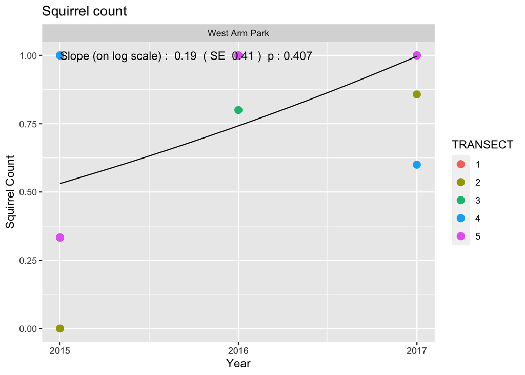

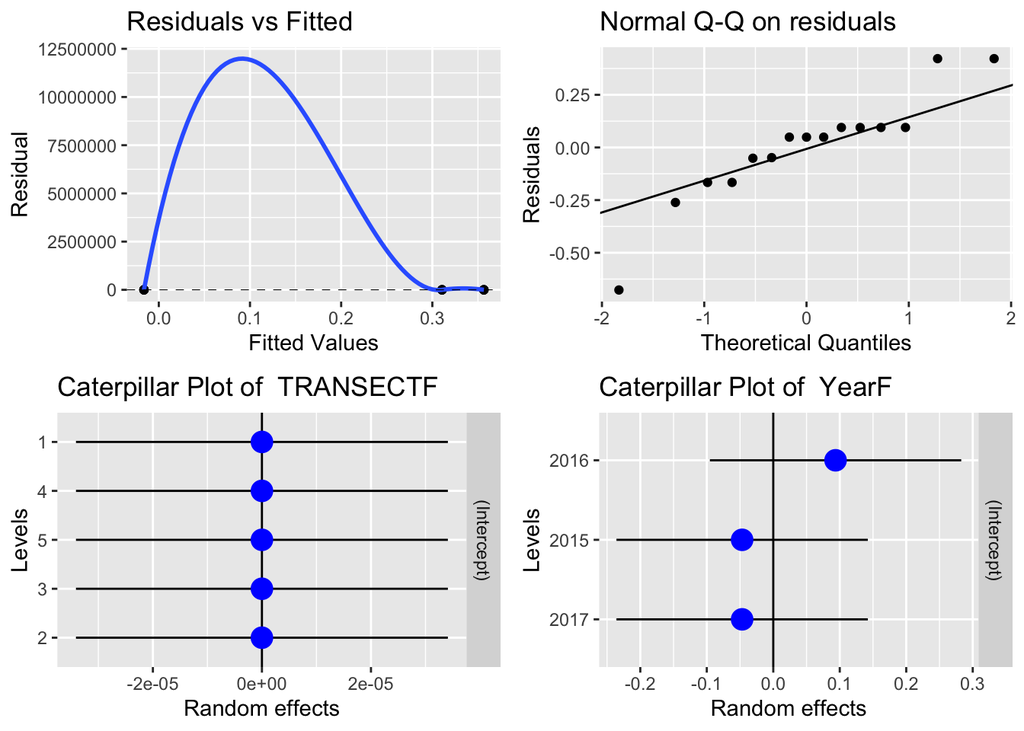

Figure 3: Model fit diagnostic plots from trend in mean transect counts

Residual plots are presented in Figure 3. With only 3 years of data, the plots are not very informative. In the upper left corner is a plot of residuals vs. the fitted values. A good plot will show a random scatter around 0. Any large deviations from 0 should be investigated as potential outliers. In the upper right is a normal probability plot. Points should be close to the dashed reference line. Fortunately, the analysis is fairly robust against non-normality so only extreme departures are worrisome. Caterpillar plots attempt to show the distribution of the random effects. The bottom left plot shows the distribution of the transect effects. The bottom right plot shows the distribution of the year-specific effects (process variation). In this case, the estimated process variation is very small with most of points very close to 0.

It will also be possible to covariates such as mean winter temperature or degree days in the year to try and explain some of the variation over time using a multiple regression. If there is only a small number of years of data available, this may not sensible.

Whenever an analysis of a trend over time is conducted, the analysis should test and adjust for autocorrelation. Autocorrelation usually isn’t a problem (and likely cannot be detected) unless you have 10+ years of data. The test for autocorrelation commonly used is the Durbin-Watson test and the p-value is p = 0.086 for the test of no autocorrelation.

This model used the approximate analysis on the logarithm of the average counts per transect. It is possible to analyze the actual raw counts using a generalized linear mixed model – this was not done in this example because of the extreme smallness of the dataset. Once many more years are collected, this may be an alternative analysis that will more naturally deal with 0 counts without having to add a small constant.

# 4 Power analysis

A power/sample size analysis was conducted to determine the number of years of sampling needed to detect changes over time. The steps in the power/sample size analysis are:

- Compute a single number summarizing the response at this site in each year. The mean number of call is currently recorded by transect and the average over the transects will be computed.
- Analyze the log(mean response) using a simple linear regression. This will give an estimate of the combined year-specific and sampling variation around regression line (overall sd).
- Use the overall SD to estimate power and sample size requirements.

Here are the overall means for each year for each response:

```
  STUDY_AREA_NAME Year mean.calls Mean.response       Response
1   West Arm Park 2015  0.5333333     0.5333333 Calls/transect
2   West Arm Park 2016  0.9600000     0.9600000 Calls/transect
3   West Arm Park 2017  0.8914286     0.8914286 Calls/transect
```

The above data needs to be checked if there are any suspicious values.

We use the *lm()* function to fit linear regression over time on the log(scale) and obtain the combined year-specific effect (process error) plus sampling variation standard deviation (Table 1).

Table 1: Estimated residual (process + sampling) standard deviation

| Response | Process + sampling SD |
| --- | --- |
| Calls/transect | 0.1980 |

This is then used to estimate the power to detect various proportional changes over time (Figure 4).

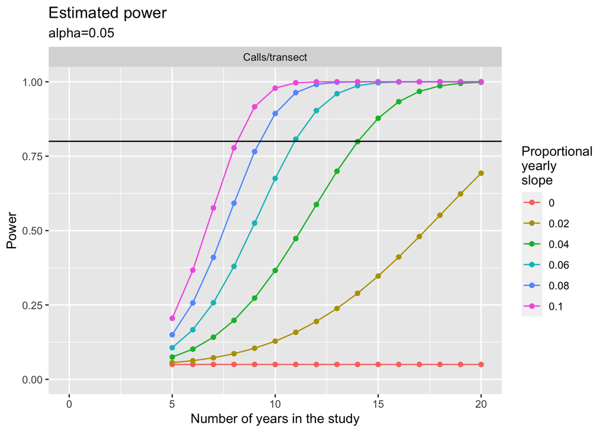

Figure 4: Estimated power to detect proportional changes over time

The proportional yearly slope indicates the effect size of interest. For example, a value of .02 would indicated a 2% change/year in the mean response.

In cases of high variability, the power is uniformly low to detect the yearly proportion change over time. In cases of low variability power is uniformly very high to detect the yearly proportion change over time.

# 5 Summary

Some caution is required to ensure that all transects are run the same number of times in a year. In this balanced design, it is straightforward to simply sum over all measurements of transect in a year and all transects in a year have the same number of visit. It is possible to modify the analysis is only some transects are visited on a particular date with an unequal number of visits to a transect in a year. A simple way to deal with unbalance would be to delete some of the observations, but better methods are available.